# Lab 4

Chi Sun

2023-11-19

## Data Loading and Preprocessing

Extracts song titles and lyrics from each file and combines them into a single data frame `lyrics_df`.

Filters out empty lyrics and assigns unique identifiers `(line_id, line_number)` to each line of lyrics.

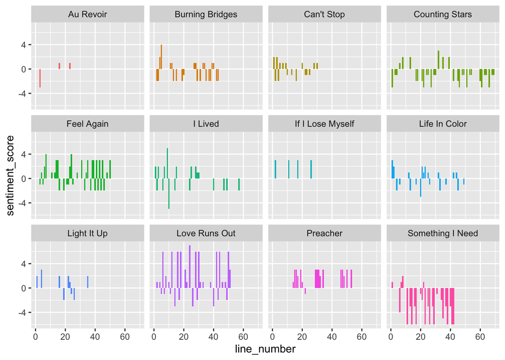

```r
library(tidytext)
library(textdata)
library(tidyverse)
library(dplyr)
library(readr)
library(readtext)
library(stringr)
library(purrr)

txt_directory <- "/Users/qihangsun/Documents/GitHub/EAS648-Lab4"
file_paths <- list.files(txt_directory, pattern = "\\.txt$", full.names = TRUE)
afinn = get_sentiments("afinn")

lyrics_list <- lapply(file_paths, function(file_path) {
  lines <- readLines(file_path, warn = FALSE)
  song_title <- lines[1]
  lyrics <- lines[-1]
  tibble(song_title = song_title, lyrics = lyrics)
})

lyrics_df <- bind_rows(lyrics_list)

lyrics_df <- lyrics_df %>%
  filter(lyrics != "" & !is.na(lyrics))

lyrics_df <- lyrics_df %>%
  mutate(line_id = row_number()) %>%
  group_by(song_title) %>%
  mutate(line_number = row_number()) %>%
  ungroup()

song_sentiment <- lyrics_df %>%
  unnest_tokens(word, lyrics) %>%
  inner_join(get_sentiments("afinn"), by = "word") %>%
  group_by(song_title, line_number) %>%
  summarize(sentiment_score = sum(value), .groups = 'drop') %>%
  ungroup()
  # Now, if you want to aggregate this to the song level:
  # group_by(song_title) %>%
  # summarize(total_sentiment = sum(sentiment_score), .groups = 'drop')

ggplot(song_sentiment, aes(line_number, sentiment_score, fill = song_title)) +
  geom_col(show.legend = FALSE) +
  facet_wrap(~song_title)
```

## Sentiment Analysis Using AFINN

Tokenizes the lyrics and joins them with the AFINN sentiment lexicon to calculate sentiment scores for each line. Summarizes sentiment scores at the song and line level. Visualizes the sentiment score for each line using `ggplot2` .

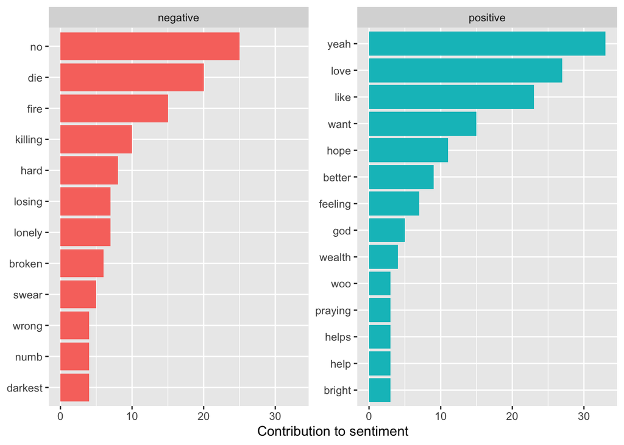

```r
afinn_word_counts <- lyrics_df %>%
  unnest_tokens(word, lyrics) %>%
  inner_join(afinn, by = "word") %>%
  mutate(sentiment = case_when(
    value > 0 ~ "positive",
    value < 0 ~ "negative",
    TRUE ~ "neutral" # 如果有词汇的情感值为0
  )) %>%
  count(word, sentiment, sort = TRUE)

afinn_word_counts %>%
  group_by(sentiment) %>%
  top_n(10) %>%
  ungroup() %>%
  mutate(word = reorder(word, n)) %>%
  ggplot(aes(word, n, fill = sentiment)) +
  geom_col(show.legend = FALSE) +
  facet_wrap(~sentiment, scales = "free_y") +
  labs(y = "Contribution to sentiment",
       x = NULL) +
  coord_flip()
```

## Word Count Analysis

Further analyzes the words in `lyrics_df` using AFINN, categorizing them as positive, negative. Counts the frequency of each word by sentiment and visualizes the top contributing words to each sentiment category using a bar plot. Generates a word cloud based on word frequencies in the lyrics, excluding stopwords. Creates a comparison cloud using sentiment data from the AFINN lexicon.

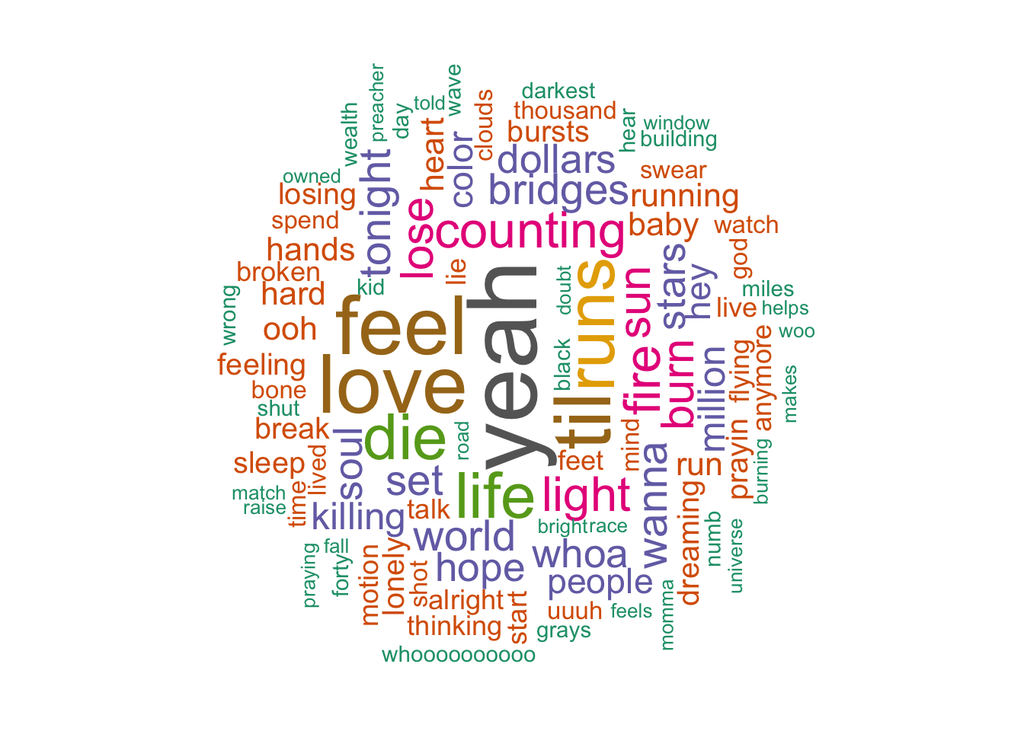

```r
library(wordcloud)
library(reshape2)
word_counts <- lyrics_df %>%
  unnest_tokens(word, lyrics) %>%
  anti_join(stop_words, by = "word") %>%
  count(word, sort = TRUE)
# word_counts = filter(word_counts,word != "yeah")
wordcloud(words = word_counts$word, freq = word_counts$n, min.freq = 1,
          max.words = 100, random.order = FALSE, rot.per = 0.35,
          colors = brewer.pal(8, "Dark2"))
```

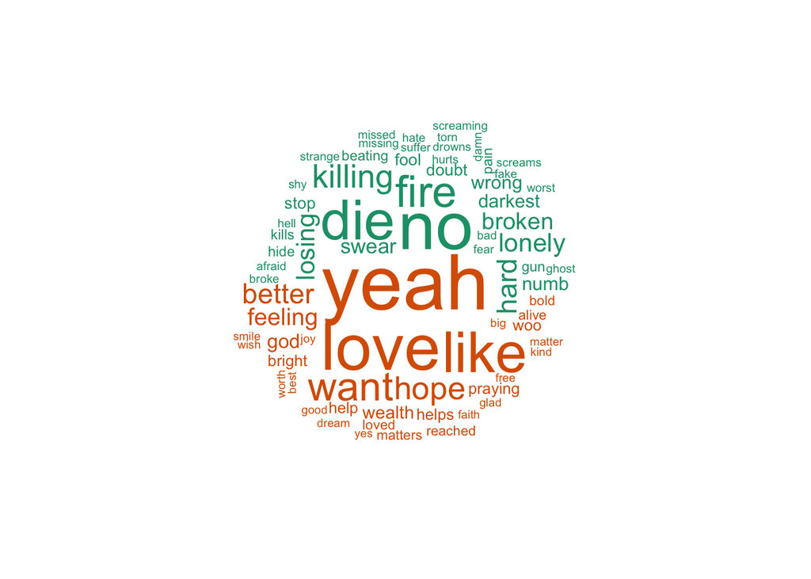

```r
comparison_data <- acast(afinn_word_counts, word ~ sentiment, value.var = "n", fill = 0)
comparison.cloud(comparison_data, max.words = 100, random.order = FALSE,
                 colors = brewer.pal(8, "Dark2"))
```

## Sentiment Analysis Using sentimentr

Conducts sentiment analysis on the lyrics using the `sentimentr` package and visualizes the average sentiment for each line.

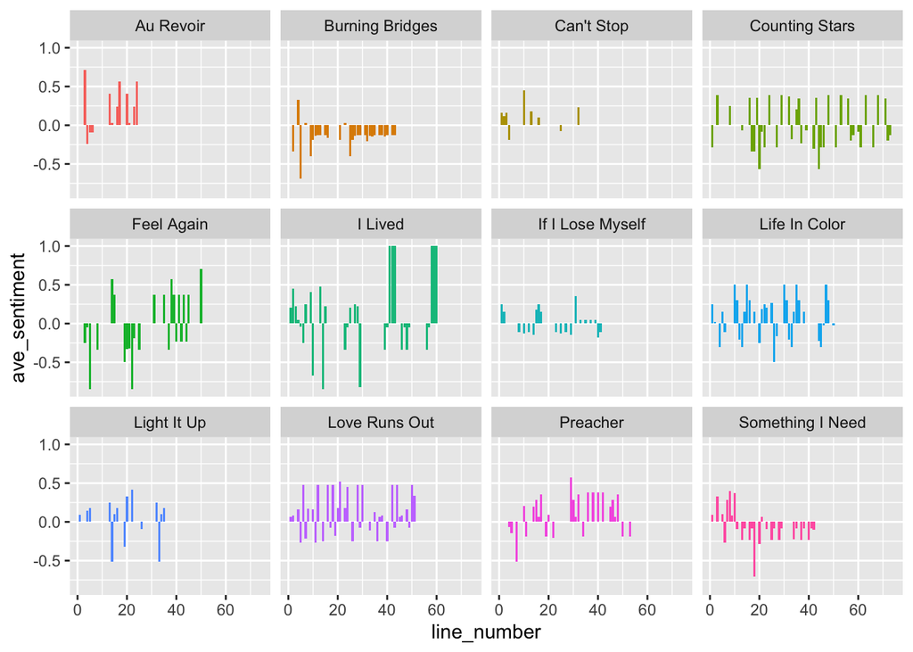

```r
library(sentimentr)

song_sentiment_sent <- lyrics_df %>%
    get_sentences() %>%
    sentiment_by(by = c('song_title', 'line_number'))%>%
  as.data.frame()

ggplot(song_sentiment_sent, aes(line_number, ave_sentiment, fill = song_title)) +
  geom_col(show.legend = FALSE) +
  facet_wrap(~song_title)
```

## Comparison of Sentiment Analysis Methods

Compares the sentiment scores obtained from the single word estimation and whole sentence estimation. Identifies the lines with the greatest differences in sentiment scores between the two methods.

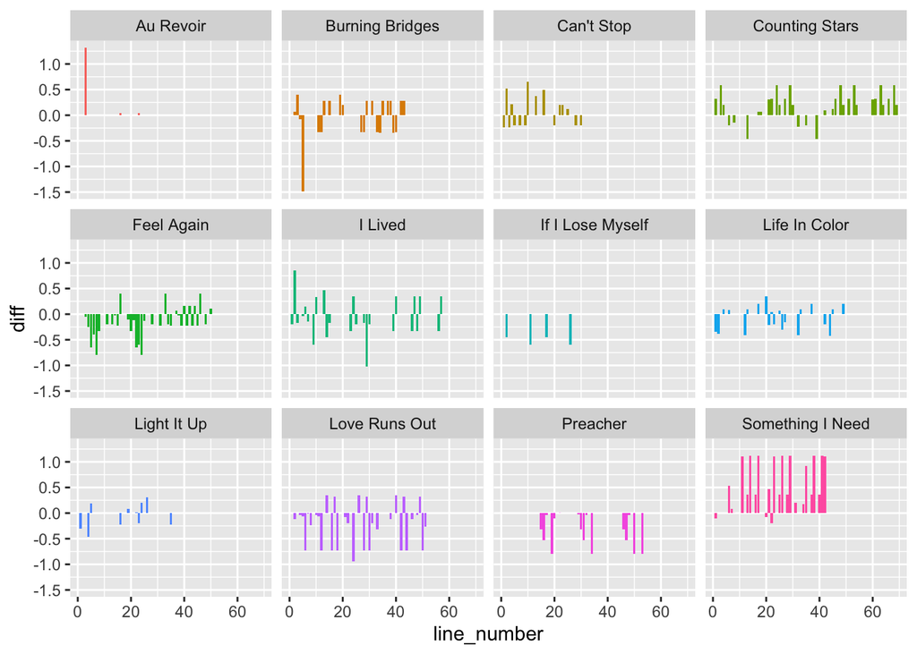

```r
comp = inner_join(song_sentiment,song_sentiment_sent, by = c("song_title","line_number"))
comp <- comp %>%
  mutate(scaled_score = sentiment_score / 5) %>%
  mutate(diff = ave_sentiment - scaled_score) %>%
  mutate(label = case_when(
    diff > 0 ~ "More Positive Than Expected",
    diff < 0 ~ "More Negative Than Expected",
    TRUE ~ "As Expected"
  ))

ggplot(comp, aes(line_number, diff, fill = song_title)) +
  geom_col(show.legend = FALSE) +
  facet_wrap(~song_title)
```

## Final Analysis and Wordcloud of Differences

Filters lines where the sentiment difference > 0.5 or < -0.5. Joins this filtered data with the original lyrics data and tokenizes the lyrics. Creates a final word cloud visualizing the words from lines with significant sentiment differences.

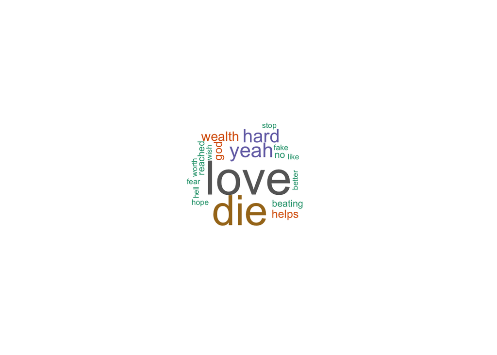

```r
top_differences <- comp %>%
  arrange(desc(diff))

Spec <- comp %>%
  filter(diff>0.5 | diff < -0.5) %>%
  arrange(song_title) %>%
  select(song_title, line_number, diff,label)

Disp <- inner_join(Spec, lyrics_df, by = c("song_title","line_number"))
Disp$lyrics2 = Disp$lyrics
Disp<- unnest_tokens(Disp,word,lyrics2) %>%
  inner_join(afinn, by = "word") %>%
  select(song_title, line_number, diff, lyrics, word,label)

word_freq <- Disp %>%
  count(word)

set.seed(123)
wordcloud(words = word_freq$word, freq = word_freq$n, min.freq = 1,
          max.words = 100, random.order = FALSE, rot.per = 0.25,
          colors = brewer.pal(8, "Dark2"))
```

```r
headfile <- Disp %>%
  arrange(diff) %>%
  select(word,lyrics,label)
options(width = 1000
)
print(headfile , n = Inf)
```

```
## # A tibble: 83 × 3
##    word    lyrics                                                       label
##    <chr>   <chr>                                                        <chr>
##  1 better  Ain't nothing better worth imagining                         More Negative Than Expected
##  2 worth   Ain't nothing better worth imagining                         More Negative Than Expected
##  3 wish    I wish that I could witness                                  More Negative Than Expected
##  4 love    'Til the love runs out, 'til the love runs out, yeah.        More Negative Than Expected
##  5 love    'Til the love runs out, 'til the love runs out, yeah.        More Negative Than Expected
##  6 yeah    'Til the love runs out, 'til the love runs out, yeah.        More Negative Than Expected
##  7 reached I reached out trying to love but I feel nothing              More Negative Than Expected
##  8 love    I reached out trying to love but I feel nothing              More Negative Than Expected
##  9 reached I reached out trying to love but I feel nothing              More Negative Than Expected
## 10 love    I reached out trying to love but I feel nothing              More Negative Than Expected
## 11 wealth  But you could never spend his wealth                         More Negative Than Expected
## 12 wealth  But you could never spend his wealth                         More Negative Than Expected
```

[output cut: 71 more lines]

From the Wordcloud I sort out the words that are most easily to be wrongly classified. And, the table shows us how these words are counted wrongly.

From the table, we can drawn the conclusion that using the whole sentence to conduct sentiment estimation is more accurate than using unicharaters. Like

[figure not shown]

However there are more complex context for sentiment estimation. Like:

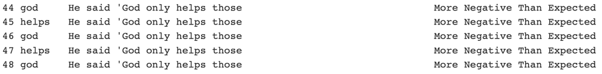

In this case, `sentimentr` considers this sentence to be A NEGATIVE ONE. And it was, if we just see this single sentence. However, the sentence follows this one is “Who learn to help themselves”. The tone of the sentences can be totally different when we variate the detection scale.